# Presentación HTML con reveal.js

realizada con RStudio

Miguel Sevilla-Callejo

October 16, 2018

# Documentación

## Instalación paquete revealjs

Note that the revealjs_presentation format is not contained within the rmarkdown package but rather in a separate revealjs package. You can use this format in R Markdown documents by installing this package as follows:

```r
install.packages("revealjs")
```

## Enlaces y documentación de interés

- Documentation: [Presentations with reveal.js](https://rmarkdown.rstudio.com/revealjs_presentation_format)
- [CRAN - Package revealjs](https://cran.r-project.org/web/packages/revealjs/index.html)
- [Reveal.js tutorial | Reveal.js Step by Step for Beginners](http://htmlcheats.com/reveal-js/reveal-js-tutorial-reveal-js-for-beginners/)

# Configuración general de la presentación

## Appearance and Style

There are several options that control the appearance of revealjs presentations:

`theme` specifies the **theme to use for the presentation**

- available themes are “default”, “simple”, “sky”, “beige”, “serif”, “solarized”, “blood”, “moon”, “night”, “black”, “league” or “white”.
- [reveal.js – The HTML Presentation Framework](https://revealjs.com/#/themes)

`highlight` specifies the **syntax highlighting style**.

- Supported styles include “default”, “tango”, “pygments”, “kate”, “monochrome”, “espresso”, “zenburn”, and “haddock”. Pass null to prevent syntax highlighting.

`center` specifies whether you want to **vertically center content on slides** (this defaults to false).

`smart` indicates whether to produce typographically correct output, converting straight quotes to curly quotes, — to em-dashes, – to en-dashes, and … to ellipses. Note that smart is enabled by default.

## Apariencia y estilo

- `theme: sky` clarito
- `theme: night` oscuro-negro
- `theme: beige` mola el tip ode letra
- Centrado de texto

`center: true` - centrado horizontal

## Incluir diapositivas en vertical

You can use the slide_level option to specify which level of heading will be used to denote individual slides. If slide_level is 2 (the default), a two-dimensional layout will be produced, with level 1 headers building horizontally and level 2 headers building vertically. For example:

```markdown
# Horizontal Slide 1

- bullet 1
- bullet 2

## Vertical Slide 1

## Vertical Slide 2

# Horizontal Slide 2
```

## Incremental Bullets

- You can render bullets incrementally by adding the incremental option:

```markdown
---
output:
  revealjs::revealjs_presentation:
    incremental: true
---
```

- If you want to render bullets incrementally for some slides but not others you can use this syntax:

```markdown
> - Eat eggs
> - Drink coffee
```

# Diapositivas base

## Enumeración

- Una cosa
- Otra cosa
- La de más alla

## Tablas 1

Fruit

Price

Advantages

Bananas

$1.34

- built-in wrapper
- bright color

Oranges

$2.10

- cures scurvy
- tasty

## Tablas 2

| Fruit | Price | Advantages |
| --- | --- | --- |
| Bananas | $1.34 | - built-in wrapper |
|  |  | - bright color |
| Oranges | $2.10 | - cures scurvy |
|  |  | - tasty |

## Imágenes

Aquí una imagen

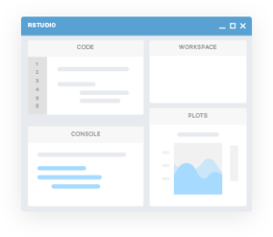

## Embeber un vídeo de youtube

[figure not shown]

[Enlace a video original](https://www.youtube.com/watch?v=jZ_iIGmi9ks)

NO SE EMBEBE

# Pruebas cambio de contenido

## Cambios del téxto

Se incrustan códigos HTML y lísto

Color

Texto con color rojo

Código: `<font color="red">Texto con color rojo</font>`

Tipo de letra (verdana)

This is some text!

Código: `<font face="verdana">This is some text!</font>`

# Pruebas cambios de fondo

- Bullet 1
- Bullet 2
- Bullet 3

Cambiado color de fondo background Código: `## Slide with Bullets {data-background=#ff0000}`

## Título - con vídeo

Esta diapo tiene un vídeo de fondo

## Título - con imagen

Esta diapo tiene una imagen de fondo

## Embed a web page as a background

## Transiciones de fondo

Tranisicón de fondo NO FUNCIONA

# Ejemplos de diapositivas con código y salidas de R

## Slide with R Output

```r
summary(cars)
```

```
##      speed           dist
##  Min.   : 4.0   Min.   :  2.00
##  1st Qu.:12.0   1st Qu.: 26.00
##  Median :15.0   Median : 36.00
##  Mean   :15.4   Mean   : 42.98
##  3rd Qu.:19.0   3rd Qu.: 56.00
##  Max.   :25.0   Max.   :120.00
```

## Slide with Plot

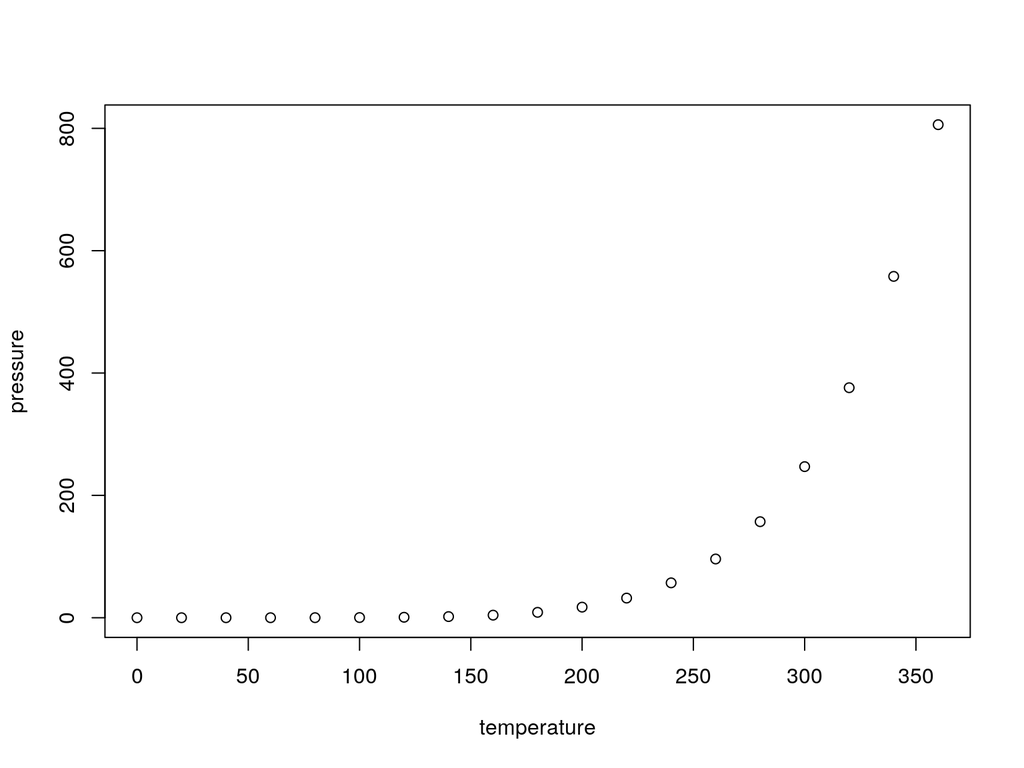